# Fake News Sentiment and Topic Modelling

## Task 1 – Sentiment Analysis

We use the HuggingFace Transformers `pipeline` with `distilbert-base-uncased-finetuned-sst-2-english`, exactly as demonstrated in **L4_LLMs.ipynb**.

Code cell 7

```
from transformers import pipeline

# Initialise the sentiment analysis pipeline – exactly as taught in L4
classifier = pipeline(
    'sentiment-analysis',
    model='distilbert-base-uncased-finetuned-sst-2-english',
    device=0
)
```

```
vocab.txt: 0.00B [00:00, ?B/s]
```

Code cell 8

```
# Quick test on a single sentence (as shown in L4)
classifier('This is quite difficult')
```

```
[{'label': 'NEGATIVE', 'score': 0.9988662004470825}]
```

Code cell 9

```
# DistilBERT truncates at 512 tokens – truncate long texts first
df['text_truncated'] = df['text'].apply(lambda x: str(x)[:1000])

# Batch sentiment analysis on the full dataset (as shown in L4)
try:
    results = classifier(df['text_truncated'].tolist(), batch_size=64, truncation=True)
except Exception as e:
    print(f'An error occurred: {e}')

# Extract label and score – same pattern as L4
labels = [item['label'] for item in results]
scores = [item['score'] for item in results]

df['sentiment_label'] = labels
df['sentiment_score']  = scores

df[['text', 'label', 'sentiment_label', 'sentiment_score']].head(10)
```

|  | text | label | sentiment_label | sentiment_score |
| --- | --- | --- | --- | --- |
| 0 | Get the latest from TODAY Sign up for our news... | 1 | NEGATIVE | 0.960733 |
| 1 | 2d Conan On The Funeral Trump Will Be Invited... | 1 | POSITIVE | 0.924247 |
| 2 | It’s safe to say that Instagram Stories has fa... | 0 | POSITIVE | 0.999351 |
| 3 | Much like a certain Amazon goddess with a lass... | 0 | POSITIVE | 0.922881 |
| 4 | At a time when the perfect outfit is just one ... | 0 | POSITIVE | 0.970188 |
| 5 | When Reese Witherspoon was 17, she had already... | 0 | POSITIVE | 0.998694 |
| 6 | It’s official! WAGS Miami stars Ashley Nicole ... | 0 | POSITIVE | 0.998111 |
| 7 | On March 24, 2018, one month and ten days afte... | 1 | NEGATIVE | 0.979555 |
| 8 | A mosque in Georgia is under fire after they s... | 1 | POSITIVE | 0.928169 |
| 9 | Scott Disick is sticking up for Khloe Kardashi... | 1 | NEGATIVE | 0.527639 |

Code cell 10

```
from scipy.stats import chi2_contingency
import numpy as np

df['sentiment_binary'] = (df['sentiment_label'] == 'POSITIVE').astype(int)

sentiment_summary = df.groupby('label').agg(
    pct_positive=('sentiment_binary', 'mean'),
    mean_score=('sentiment_score', 'mean'),
    count=('label', 'count')
).round(4)
sentiment_summary.index = sentiment_summary.index.map({0: 'Real/Normal', 1: 'Fake/Spam'})
print(sentiment_summary)

contingency = pd.crosstab(df['label'], df['sentiment_label'])
chi2, p, dof, expected = chi2_contingency(contingency)
print(f'\nChi-square = {chi2:.2f}, p-value = {p:.4e}')
print(f"Result: {'Statistically significant' if p < 0.05 else 'Not significant'} (p < 0.05)")
```

```
             pct_positive  mean_score  count
label
Real/Normal        0.5456      0.9454   2925
Fake/Spam          0.4324      0.9517   1968

Chi-square = 59.87, p-value = 1.0116e-14
Result: Statistically significant (p < 0.05)
```

Code cell 11

```
import matplotlib.pyplot as plt

PALETTE = {'Fake/Spam': '#E63946', 'Real/Normal': '#457B9D'}

fig, axes = plt.subplots(1, 3, figsize=(15, 4))
fig.suptitle('Task 1 – Sentiment Analysis: Fake vs Real News', fontsize=13, fontweight='bold')

for lbl in [0, 1]:
    name = 'Fake/Spam' if lbl == 1 else 'Real/Normal'
    subset = df[df['label'] == lbl]
    pct = (subset['sentiment_label'] == 'POSITIVE').mean() * 100
    axes[0].bar(name, pct, color=PALETTE[name], alpha=0.8)
axes[0].set_title('% POSITIVE Sentiment by Class')
axes[0].set_ylabel('% POSITIVE')
axes[0].set_ylim(0, 100)

for lbl in [0, 1]:
    name = 'Fake/Spam' if lbl == 1 else 'Real/Normal'
    axes[1].hist(df.loc[df['label'] == lbl, 'sentiment_score'],
                 bins=30, alpha=0.55, label=name, color=PALETTE[name], density=True)
axes[1].set_title('Confidence Score Distribution')
axes[1].set_xlabel('Score')
axes[1].set_ylabel('Density')
axes[1].legend()

for i, lbl in enumerate([0, 1]):
    name = 'Fake/Spam' if lbl == 1 else 'Real/Normal'
    subset = df[df['label'] == lbl]
    pos = (subset['sentiment_label'] == 'POSITIVE').mean() * 100
    axes[2].bar(name, pos, color='#2A9D8F', alpha=0.85, label='POSITIVE' if i == 0 else '')
    axes[2].bar(name, 100 - pos, bottom=pos, color='#E76F51', alpha=0.85, label='NEGATIVE' if i == 0 else '')
axes[2].set_title('POSITIVE vs NEGATIVE Mix')
axes[2].set_ylabel('Proportion (%)')
axes[2].legend()

plt.tight_layout()
plt.show()
```

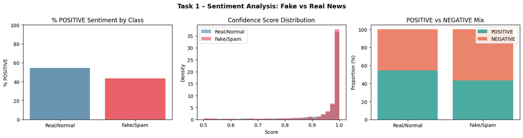

Code cell 12

```
fake_pos = (df.loc[df['label']==1, 'sentiment_label'] == 'POSITIVE').mean() * 100
real_pos = (df.loc[df['label']==0, 'sentiment_label'] == 'POSITIVE').mean() * 100
direction = 'HIGHER' if fake_pos > real_pos else 'LOWER'

print(f'Fake/Spam   – % POSITIVE: {fake_pos:.1f}%')
print(f'Real/Normal – % POSITIVE: {real_pos:.1f}%')
print(f'\n>>> Sentiment for FAKE/SPAM messages is {direction} than REAL/NORMAL.')
print(f'>>> p-value = {p:.4e} → {"Statistically significant" if p < 0.05 else "Not significant"}')
```

```
Fake/Spam   – % POSITIVE: 43.2%
Real/Normal – % POSITIVE: 54.6%

>>> Sentiment for FAKE/SPAM messages is LOWER than REAL/NORMAL.
>>> p-value = 1.0116e-14 → Statistically significant
```

Markdown cell 13

## Task 2 – Topic Modelling (LDA)

Code cell 14

```
import re

STOPWORDS = set("""
i me my myself we our ours ourselves you your yours yourself he him his
himself she her hers herself it its itself they them their theirs themselves
what which who whom this that these those am is are was were be been being
have has had having do does did doing a an the and but if or because as
until while of at by for with about against between into through during
before after above below to from up down in out on off over under again
further then once here there when where why how all both each few more most
other some such no nor not only own same so than too very s t can will just
don should now d ll m o re ve y said also would could one like get got even
still back going say think know people new see well first two time years year
mr ms us may many made make since took take way day look come came last
source watch link site facebook twitter google
""".split())

def preprocess(text):
    text = str(text).lower()
    text = re.sub(r'http\S+|www\S+', ' ', text)
    text = re.sub(r'[^a-z\s]', ' ', text)
    return ' '.join(w for w in text.split() if w not in STOPWORDS and len(w) > 2)

df['clean_text'] = df['text'].apply(preprocess)
print('Pre-processing done.')
```

```
Pre-processing done.
```

Code cell 15

```
from sklearn.feature_extraction.text import CountVectorizer

vectorizer = CountVectorizer(max_features=5000, min_df=5, max_df=0.90)
dtm   = vectorizer.fit_transform(df['clean_text'])
vocab = vectorizer.get_feature_names_out()
print(f'Document-Term Matrix: {dtm.shape[0]:,} docs x {dtm.shape[1]:,} terms')
```

```
Document-Term Matrix: 4,893 docs x 5,000 terms
```

Code cell 16

```
from sklearn.decomposition import LatentDirichletAllocation

k_range = range(2, 11)
perplexities   = []
log_likelihoods = []

for k in k_range:
    lda_tmp = LatentDirichletAllocation(
        n_components=k, random_state=42, max_iter=10,
        learning_method='online', batch_size=256
    )
    lda_tmp.fit(dtm)
    perplexities.append(lda_tmp.perplexity(dtm))
    log_likelihoods.append(lda_tmp.score(dtm))
    print(f'k={k:2d}  perplexity={perplexities[-1]:.1f}  log-likelihood={log_likelihoods[-1]:.0f}')

best_k = list(k_range)[int(np.argmin(perplexities))]
print(f'\n>>> Optimal number of topics (lowest perplexity): k = {best_k}')
```

```
k= 2  perplexity=2597.5  log-likelihood=-8367570
k= 3  perplexity=2449.4  log-likelihood=-8305121
k= 4  perplexity=2327.5  log-likelihood=-8250757
k= 5  perplexity=2309.0  log-likelihood=-8242300
k= 6  perplexity=2225.5  log-likelihood=-8203087
k= 7  perplexity=2166.0  log-likelihood=-8174235
k= 8  perplexity=2120.7  log-likelihood=-8151751
k= 9  perplexity=2108.5  log-likelihood=-8145624
k=10  perplexity=2089.7  log-likelihood=-8136054

>>> Optimal number of topics (lowest perplexity): k = 10
```

Code cell 17

```
ks = list(k_range)
plt.figure(figsize=(12, 4))

plt.subplot(1, 2, 1)
plt.plot(ks, perplexities, 's-', color='#E76F51', linewidth=2, markersize=7)
plt.axvline(best_k, color='red', linestyle='--', label=f'Optimal k={best_k}')
plt.title('Perplexity vs Number of Topics (lower = better)')
plt.xlabel('Number of Topics (k)')
plt.ylabel('Perplexity')
plt.legend()
plt.grid(True)

plt.subplot(1, 2, 2)
plt.plot(ks, log_likelihoods, 'o-', color='#2A9D8F', linewidth=2, markersize=7)
plt.axvline(best_k, color='red', linestyle='--', label=f'Optimal k={best_k}')
plt.title('Log-Likelihood vs Number of Topics (higher = better)')
plt.xlabel('Number of Topics (k)')
plt.ylabel('Log-Likelihood')
plt.legend()
plt.grid(True)

plt.tight_layout()
plt.show()
```

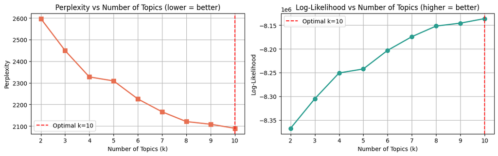

Code cell 18

```
lda = LatentDirichletAllocation(
    n_components=best_k, random_state=42, max_iter=25,
    learning_method='online', batch_size=256
)
doc_topic_matrix = lda.fit_transform(dtm)
df['dominant_topic'] = doc_topic_matrix.argmax(axis=1)
print(f'Model fitted with k = {best_k} topics.')
```

```
Model fitted with k = 10 topics.
```

Code cell 19

```
N_TOP_WORDS = 10
print('Top words per topic:\n')
for t_idx, topic_vec in enumerate(lda.components_):
    top_words = [vocab[i] for i in topic_vec.argsort()[:-N_TOP_WORDS-1:-1]]
    print(f'  Topic {t_idx}: {", ".join(top_words)}')
```

```
Top words per topic:

  Topic 0: music, album, song, kanye, taylor, swift, video, top, singer, single
  Topic 1: kardashian, getty, images, kim, jenner, photo, york, scott, city, ellen
  Topic 2: harry, prince, wedding, meghan, markle, royal, kate, queen, family, william
  Topic 3: season, show, series, best, episode, edit, cast, live, television, abc
  Topic 4: blake, shelton, gwen, stefani, super, lambert, manchester, concert, voice, chris
  Topic 5: together, justin, brad, selena, couple, relationship, pitt, gomez, bieber, jennifer
  Topic 6: film, women, role, sexual, weinstein, actress, million, hollywood, actor, movie
  Topic 7: news, instagram, family, old, shared, love, star, photo, wrote, video
  Topic 8: really, says, want, kylie, life, love, told, didn, things, much
  Topic 9: trump, president, obama, donald, white, house, states, united, country, state
```

Code cell 20

```
topic_vs_label = (
    df.groupby(['dominant_topic', 'class'])
      .size()
      .unstack(fill_value=0)
)
topic_vs_label['Total'] = topic_vs_label.sum(axis=1)
topic_vs_label['Fake%'] = (topic_vs_label.get('Fake/Spam', 0) / topic_vs_label['Total'] * 100).round(1)
topic_vs_label['Nature'] = topic_vs_label['Fake%'].apply(
    lambda x: 'Predominantly Fake' if x > 60
    else ('Predominantly Real' if x < 40 else 'Mixed')
)
print(topic_vs_label.to_string())
```

```
class           Fake/Spam  Real/Normal  Total  Fake%              Nature
dominant_topic
0                      69          194    263   26.2  Predominantly Real
1                      33           43     76   43.4               Mixed
2                     102          211    313   32.6  Predominantly Real
3                      95          459    554   17.1  Predominantly Real
4                      38           43     81   46.9               Mixed
5                     479          202    681   70.3  Predominantly Fake
6                     145          234    379   38.3  Predominantly Real
7                     139          619    758   18.3  Predominantly Real
8                     577          692   1269   45.5               Mixed
9                     291          228    519   56.1               Mixed
```

Code cell 21

```
pivot = df.groupby(['dominant_topic','class']).size().unstack(fill_value=0)
pivot_pct = pivot.div(pivot.sum(axis=1), axis=0) * 100

fig, axes = plt.subplots(1, 2, figsize=(13, 5))
fig.suptitle('Task 2 – Topic Distribution vs Fake / Real Label', fontsize=13, fontweight='bold')

pivot_pct.plot(kind='bar', stacked=True,
               color=['#E63946', '#457B9D'],
               ax=axes[0], edgecolor='white', width=0.6)
axes[0].axhline(50, color='black', linestyle='--', linewidth=0.8, alpha=0.6)
axes[0].set_title('Class Mix per Topic (%)')
axes[0].set_xlabel('Topic')
axes[0].set_ylabel('Proportion (%)')
axes[0].set_xticklabels([f'T{i}' for i in pivot_pct.index], rotation=0)
axes[0].legend(title='Class')

n_cols = min(best_k, 5)
n_rows = (best_k + n_cols - 1) // n_cols
cmap_fn = plt.cm.get_cmap('tab10')

fig2, axes2 = plt.subplots(n_rows, n_cols, figsize=(n_cols * 4, n_rows * 3.5))
axes2 = np.array(axes2).flatten()
fig2.suptitle('Top 10 Words per Topic', fontsize=13, fontweight='bold')

for t_idx, topic_vec in enumerate(lda.components_):
    top_idx   = topic_vec.argsort()[:-N_TOP_WORDS-1:-1]
    top_words = [vocab[i] for i in top_idx]
    top_wts   = topic_vec[top_idx] / topic_vec[top_idx].sum()
    axes2[t_idx].barh(top_words[::-1], top_wts[::-1], color=cmap_fn(t_idx), alpha=0.8)
    fk  = topic_vs_label.loc[t_idx, 'Fake%']  if t_idx in topic_vs_label.index else 0
    nat = topic_vs_label.loc[t_idx, 'Nature'] if t_idx in topic_vs_label.index else ''
    axes2[t_idx].set_title(f'Topic {t_idx}  ({fk:.0f}% Fake)\n[{nat}]', fontsize=9)
    axes2[t_idx].tick_params(labelsize=8)

for j in range(best_k, len(axes2)):
    axes2[j].set_visible(False)

plt.tight_layout()
plt.show()
```

[figure not shown]

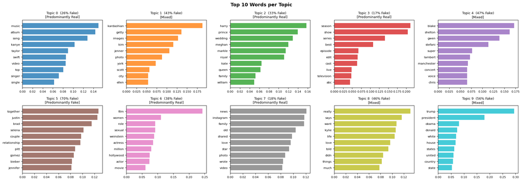

Code cell 22

```
print(f'Optimal number of topics: k = {best_k}\n')
print('Topic → Fake/Real relationship:\n')
for t in range(best_k):
    top5 = [vocab[i] for i in lda.components_[t].argsort()[:-6:-1]]
    fk  = topic_vs_label.loc[t, 'Fake%']  if t in topic_vs_label.index else 0
    nat = topic_vs_label.loc[t, 'Nature'] if t in topic_vs_label.index else ''
    print(f'  Topic {t}  [{nat}]  ({fk:.0f}% Fake)')
    print(f'    Keywords: {", ".join(top5)}')
    print()
```

```
Optimal number of topics: k = 10

Topic → Fake/Real relationship:

  Topic 0  [Predominantly Real]  (26% Fake)
    Keywords: music, album, song, kanye, taylor

  Topic 1  [Mixed]  (43% Fake)
    Keywords: kardashian, getty, images, kim, jenner

  Topic 2  [Predominantly Real]  (33% Fake)
    Keywords: harry, prince, wedding, meghan, markle

  Topic 3  [Predominantly Real]  (17% Fake)
    Keywords: season, show, series, best, episode

  Topic 4  [Mixed]  (47% Fake)
    Keywords: blake, shelton, gwen, stefani, super

  Topic 5  [Predominantly Fake]  (70% Fake)
    Keywords: together, justin, brad, selena, couple

  Topic 6  [Predominantly Real]  (38% Fake)
    Keywords: film, women, role, sexual, weinstein

  Topic 7  [Predominantly Real]  (18% Fake)
    Keywords: news, instagram, family, old, shared

  Topic 8  [Mixed]  (46% Fake)
    Keywords: really, says, want, kylie, life

  Topic 9  [Mixed]  (56% Fake)
    Keywords: trump, president, obama, donald, white
```